### Course Expectations & Requirements - GIS for International Crises, Development and the Environment

#### [CRN: 2115 | NINT 5380 | Spring 2021](https://courses.newschool.edu/courses/NINT5380/)

#### New School for Public Engagement: International Affairs | Faculty: Stephen Metts | Email

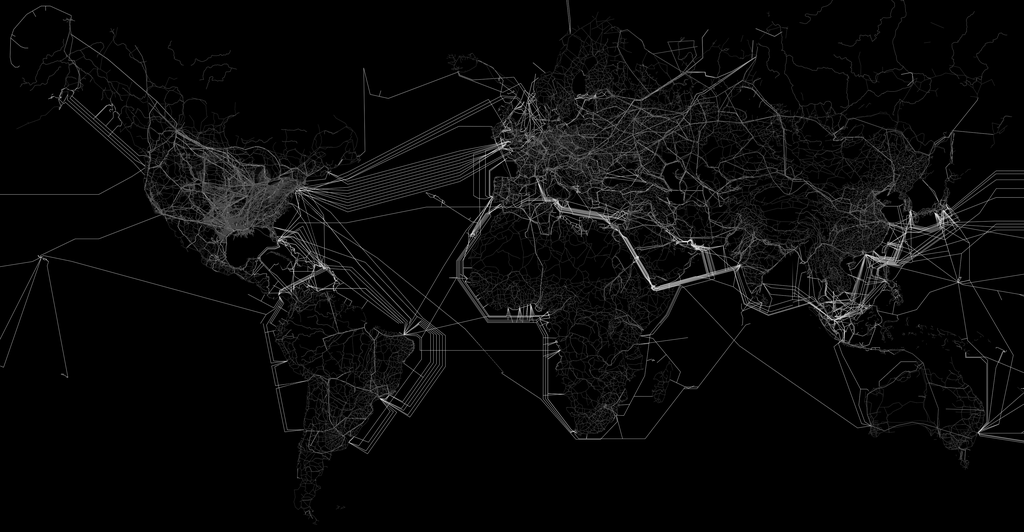

*Source: https://atlas.developmentseed.org/all/ | Connectivity Atlas*

### Course Communication:

Throughout the course, students are expected to utilize course material covered during each lecture and lab to accomplish weekly technical assignments. It is often the case that each and every technical detail is NOT addressed in the short interval that the class meets. This requires that students maintain a degree of self sufficiency in problem solving and communication to seek answers to technical blocks. The course [Slack](https://tns-gis-spring22.slack.com) team will have several channels appropriate to getting help from fellow students, the course TA and instructor.

A portion of the participation grade is devoted to good communication and problem solving strategies. Typically, each week students will receive a grade and feedback for the technical assignment of the previous week so that students are able to build on their achievements and address any technical areas for improvement to be successful throughout the course.

Asking well formed questions is a core proficiency for any technical skill, certainly for GIS. Review the following guide on best practices for seeking solutions to technical problems that will inevitably be part of the learning process in this course:

- [Asking GIS technical questions - best practices](https://gist.github.com/gis-nspe-tns/753045971941b7f5f1b59979eb0f8829)

### Data Transfer & Storage:

It is highly recommended that students utilize cloud storage for backup of each assignment as well as final project. Leaving projects and data on a computer drive without backup is not ideal. Backup your data often and in multiple locations. A USB drive will take care of basic workflow backup; but it should not be the primary backup device for your work in this class. Make sure to zip compress your work before transport to a portable drive and/or cloud storage. Cloud storage options include Google Drive, Dropbox, Box, ect.

### Core Computer Skills:

GIS is an expansive technical field. At its most advanced, it requires many adjacent technical skills, all of which can be initiated in this class. However, a prerequisite skill set is necessary to do well in this class. This includes the following:

- Beginning to intermediate database/spreadsheet skills (Excel, Google Sheets)
- FTP (Filezilla, CuteFTP, ect.)
- Saving and exporting files as PDF; screengrab captures.
- Compressing and extracting file is zip format.

If you feel that you need to brush up on these computer skills, there are many resources online- google, youtube as well as the excellent [lynda.com](https://www.lynda.com/) tutorials that are freely available to TNS students. It is your responsibility to understand how to employ these skills early in the class. Further, all students need to be signed up to the [Slack](https://join.slack.com/t/newschool-kvr2088/shared_invite/zt-11sd4ogj8-9AAb7dM4Wv7W8QzmeyBdAQ) team prior to the first class meeting - 01/24/22.

### Course Software:

This course utilizes open source software to accomplish GIS tasks. In addition to the main software component of the course - [QGIS](https://qgis.org/en/site/index.html) - there will be several utilities that are largely cross-platform that will require online access and a browser to either access or download.

### Course Management:

We will be utilizing CANVAS as the course management platform for the course. Much of the course instruction, labs, lectures are linked to CANVAS pages for each class session; however, there is not much content that resides @ CANVAS. You will use CANVAS primarily to access instruction, labs, lectures and data; and then once assignments are completed, upload your final work to the assignment submission section for each class session. Further, students are required to keep abreast of ongoing postings on the [Slack](https://tns-gis-spring22.slack.com) team and contribute their own links, tips, insights, ect. During the course, the instructor and TA will cross-post important announcements and weekly materials and links both as announcements within CANVAS, as well as @ the course Slack.

### Attendance:

As this course is highly dependent on sequential learning; that is, relying on learned skills to adopt new ones, maintaining good attendance in this course is critical. Certainly the unexpected happens, but if students display a pattern of attendance issues, its a problem. Further, it is critical to ‘get to class’ on time. For this Fall semester, this entails making sure that you are present for the lecture and online for the lab. A significant portion of the participation grade involves consistent attendance and being ready for the lecture and lab each week. Attendance will be taken for both the lab and lecture; attendance records will then be kept on a weekly basis both within CANVAS and at Starfish.

### Maintaining Account Logins:

Throughout this course we will be utilizing a Google account, as well as gaining many free site accounts through various geospatial data and technology distributors. These accounts often require logins, passwords and some email and FTP communication. It is your responsibility to keep these accounts organized in some fashion so you can readily access them both in and outside of class.

### Weekly Assignment Policy:

Weekly assignments are due prior to the next Monday class, uploaded by Sunday night at midnight (11:59pm).

- If an assignment is late, 5 points are deducted from total score during the first week.
- Assignments are posted for an additional week after the due date. Students can access assignments for this additional week.
- After the additional week, assignments submissions will close in CANVAS, and will not be graded.

### Credit Course Load:

Generally for a graduate level course of 3 credits, it is assumed that students will have a ‘homework’ load of 2-3 hours per credit. This works out to 6-9 hours per week outside of the approximately 4 hours we meet each week during lecture and lab. Although most weeks will not require this level of attention, there will be ‘harder’ weeks, and working in a bit more space in your weekly schedule for these weeks will help you master the theory and technical components of the week’s work. Generally, make sure that you schedule ample space into your Fall 2021 schedule to allow for optimum learning and mastery. It is challenging to learn effectively if you are over-scheduled and unprepared. As a rule of thumb, you should plan for the approximately 4 contact hours for the lecture and lab, and then allow for at least a half-day of relatively uninterrupted attention to complete the weekly assignment. Alternatively, pick 2-3 days following the lecture and lab and allow for separate 1-2 hour sessions for assignment completion.